# COMPSCIX 415.2 Homework 9/Final

## 2.Fit a decision tree to train_set using the rpart package, and using Pclass, Sex, Age, SibSp, Parch, Fare, Embarked as the features. Plot the tree using the partykit package. What do you notice about this tree compared to the one from last week which only contained three features?

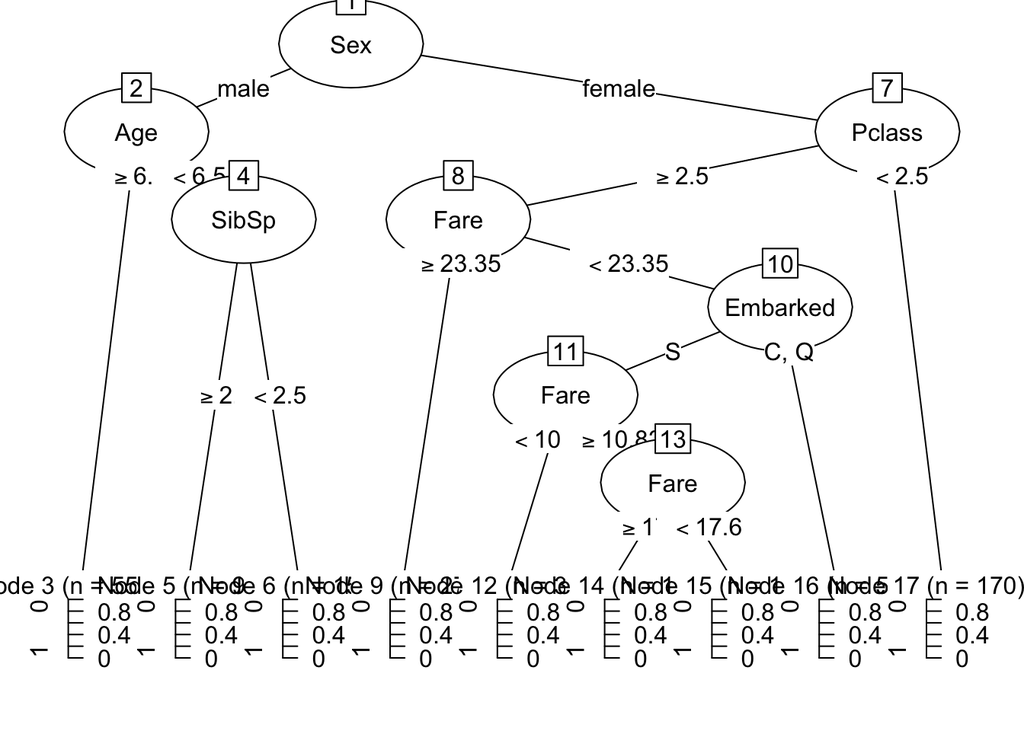

```r
#Adding more features to decision tree has caused the tree to generate more decision branches . However it seems that the most important features are still Sex, Pclass, Fare and Age.
tree_mod <- rpart(Survived ~ Pclass + Sex + Age + SibSp + Parch + Fare + Embarked, data = Train_data_1)

plot(as.party(tree_mod))
```

## 3.Fit a random forest to train_set using the randomForest package, and using Pclass, Sex, Age, SibSp, Parch, Fare, Embarked as the features. We’ll use 500 trees and sample four features at each split. Use the code below and fill in the blanks.

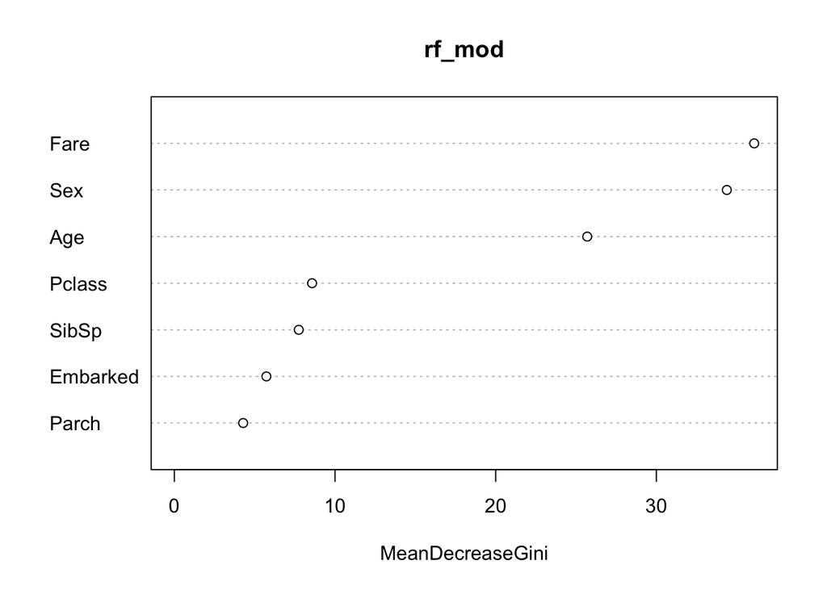

```r
rf_mod <- randomForest(Survived ~ Pclass + Sex + Age + SibSp + Parch + Fare + Embarked,
                         data = train_set,
                         ntrees = 500,
                         mtry = 4,
                         na.action = na.roughfix,
                        importance = TRUE)

varImpPlot(rf_mod, type = 2)
```

## 4. Compare the performance of the decision tree with the random forest using the ROCR package and the AUC. Which model performs the best? Here’s some code to get you started.

```r
rf_preds <- predict(rf_mod, newdata = test_set, type = 'prob')[,2]
tree_preds <- predict(tree_mod, newdata = test_set)[,2]

pred_rf <- prediction(predictions = rf_preds, labels = test_set$Survived)
pred_tree <- prediction(predictions = tree_preds, labels = test_set$Survived)
```